# R Notebook

data exploration

```r
skim(nyc_bikes)
```

```
── Data Summary ────────────────────────
                           Values
Name                       nyc_bikes
Number of rows             4268
Number of columns          12
_______________________
Column type frequency:
  factor                   5
  numeric                  5
  POSIXct                  2
________________________
Group variables            None
```

[output not shown]

[output cut: 990 more lines]

[output not shown]

[output cut: 990 more lines]

[output not shown]

[output cut: 990 more lines]

```r
nyc_bikes_df <- nyc_bikes_df %>%
  mutate(year = year(start_time),
        month = month(start_time, label = TRUE, abbr = TRUE),
        day = day(start_time, label = TRUE, abbr = TRUE),
        weekday = wday(start_time, label = TRUE, abbr = FALSE))
```

[output not shown]

```r
head(nyc_bikes_df)
```

| bike_id | start_time | stop_time | start_station | start_lat | start_long | end_station | end_lat | end_long | type | birth_year | gender | year | month | day | weekday | date | age | hire_length | hour | minute | second | length_minutes |
| --- | --- | --- | --- | --- | --- | --- | --- | --- | --- | --- | --- | --- | --- | --- | --- | --- | --- | --- | --- | --- | --- | --- |
| 26301 | 2018-02-26 19:11:03 | 2018-02-26 19:15:40 | 3186 | 40.71959 | -74.04312 | 3203 | 40.72760 | -74.04425 | Subscriber | 1986 | Male | 2018 | Feb | 26 | Monday | 2018-02-26 | 32 | 4M 37.0980000495911S | 0 | 4 | 37.098 | 5 |
| 26301 | 2018-02-27 07:52:49 | 2018-02-27 07:58:13 | 3203 | 40.72760 | -74.04425 | 3202 | 40.72722 | -74.03376 | Subscriber | 1979 | Male | 2018 | Feb | 27 | Tuesday | 2018-02-27 | 39 | 5M 23.9240000247955S | 0 | 5 | 23.924 | 5 |
| 26301 | 2018-02-27 12:03:27 | 2018-02-27 12:04:54 | 3202 | 40.72722 | -74.03376 | 3638 | 40.72429 | -74.03548 | Subscriber | 1963 | Male | 2018 | Feb | 27 | Tuesday | 2018-02-27 | 55 | 1M 26.5269999504089S | 0 | 1 | 26.527 | 1 |
| 26301 | 2018-02-27 13:53:51 | 2018-02-27 14:21:04 | 3638 | 40.72429 | -74.03548 | 3638 | 40.72429 | -74.03548 | Subscriber | 1984 | Male | 2018 | Feb | 27 | Tuesday | 2018-02-27 | 34 | 27M 12.9449999332428S | 0 | 27 | 12.945 | 27 |
| 26301 | 2018-02-27 14:30:42 | 2018-02-27 14:33:11 | 3638 | 40.72429 | -74.03548 | 3187 | 40.72112 | -74.03805 | Subscriber | 1980 | Male | 2018 | Feb | 27 | Tuesday | 2018-02-27 | 38 | 2M 28.5340001583099S | 0 | 2 | 28.534 | 2 |
| 26301 | 2018-02-27 16:31:04 | 2018-02-27 16:33:27 | 3187 | 40.72112 | -74.03805 | 3638 | 40.72429 | -74.03548 | Subscriber | 1980 | Male | 2018 | Feb | 27 | Tuesday | 2018-02-27 | 38 | 2M 23.9549999237061S | 0 | 2 | 23.955 | 2 |

```r
skim(nyc_bikes_df)
```

```
── Data Summary ────────────────────────
                           Values
Name                       nyc_bikes_df
Number of rows             4268
Number of columns          23
_______________________
Column type frequency:
  Date                     1
  factor                   7
  numeric                  12
  POSIXct                  2
  Timespan                 1
________________________
Group variables            None
```

[output not shown]

[output cut: 990 more lines]

[output not shown]

[output cut: 990 more lines]

[output not shown]

[output cut: 990 more lines]

[output not shown]

[output cut: 990 more lines]

[output not shown]

[output cut: 990 more lines]

- What is the pattern of bike hires over time (e.g. within a year, month, week, or day)?
- Do bike hire patterns differ between bike rider demographics? (e.g. gender, type of trip, age)
- Any other insights?

```r
nyc_bikes_df %>% group_by(bike_id)
```

| bike_id | start_time | stop_time | start_station | start_lat | start_long | end_station | end_lat | end_long | type | birth_year | gender | year | month | day | weekday | date | age | hire_length | hour | minute | second | length_minutes |
| --- | --- | --- | --- | --- | --- | --- | --- | --- | --- | --- | --- | --- | --- | --- | --- | --- | --- | --- | --- | --- | --- | --- |
| 26301 | 2018-02-26 19:11:03 | 2018-02-26 19:15:40 | 3186 | 40.71959 | -74.04312 | 3203 | 40.72760 | -74.04425 | Subscriber | 1986 | Male | 2018 | Feb | 26 | Monday | 2018-02-26 | 32 | 4M 37.0980000495911S | 0 | 4 | 37.098000050 | 5 |
| 26301 | 2018-02-27 07:52:49 | 2018-02-27 07:58:13 | 3203 | 40.72760 | -74.04425 | 3202 | 40.72722 | -74.03376 | Subscriber | 1979 | Male | 2018 | Feb | 27 | Tuesday | 2018-02-27 | 39 | 5M 23.9240000247955S | 0 | 5 | 23.924000025 | 5 |
| 26301 | 2018-02-27 12:03:27 | 2018-02-27 12:04:54 | 3202 | 40.72722 | -74.03376 | 3638 | 40.72429 | -74.03548 | Subscriber | 1963 | Male | 2018 | Feb | 27 | Tuesday | 2018-02-27 | 55 | 1M 26.5269999504089S | 0 | 1 | 26.526999950 | 1 |
| 26301 | 2018-02-27 13:53:51 | 2018-02-27 14:21:04 | 3638 | 40.72429 | -74.03548 | 3638 | 40.72429 | -74.03548 | Subscriber | 1984 | Male | 2018 | Feb | 27 | Tuesday | 2018-02-27 | 34 | 27M 12.9449999332428S | 0 | 27 | 12.944999933 | 27 |
| 26301 | 2018-02-27 14:30:42 | 2018-02-27 14:33:11 | 3638 | 40.72429 | -74.03548 | 3187 | 40.72112 | -74.03805 | Subscriber | 1980 | Male | 2018 | Feb | 27 | Tuesday | 2018-02-27 | 38 | 2M 28.5340001583099S | 0 | 2 | 28.534000158 | 2 |
| 26301 | 2018-02-27 16:31:04 | 2018-02-27 16:33:27 | 3187 | 40.72112 | -74.03805 | 3638 | 40.72429 | -74.03548 | Subscriber | 1980 | Male | 2018 | Feb | 27 | Tuesday | 2018-02-27 | 38 | 2M 23.9549999237061S | 0 | 2 | 23.954999924 | 2 |
| 26301 | 2018-02-27 17:37:12 | 2018-02-27 17:40:49 | 3638 | 40.72429 | -74.03548 | 3639 | 40.71925 | -74.03423 | Subscriber | 1989 | Male | 2018 | Feb | 27 | Tuesday | 2018-02-27 | 29 | 3M 36.9920001029968S | 0 | 3 | 36.992000103 | 4 |
| 26301 | 2018-02-27 17:49:10 | 2018-02-27 17:55:03 | 3639 | 40.71925 | -74.03423 | 3202 | 40.72722 | -74.03376 | Subscriber | 1962 | Male | 2018 | Feb | 27 | Tuesday | 2018-02-27 | 56 | 5M 52.8989999294281S | 0 | 5 | 52.898999929 | 6 |
| 26301 | 2018-02-27 18:21:57 | 2018-02-27 18:25:18 | 3202 | 40.72722 | -74.03376 | 3638 | 40.72429 | -74.03548 | Subscriber | 1992 | Male | 2018 | Feb | 27 | Tuesday | 2018-02-27 | 26 | 3M 20.2019999027252S | 0 | 3 | 20.201999903 | 3 |
| 26301 | 2018-02-27 22:08:55 | 2018-02-27 22:28:42 | 3638 | 40.72429 | -74.03548 | 3281 | 40.74591 | -74.05727 | Subscriber | 1981 | Male | 2018 | Feb | 27 | Tuesday | 2018-02-27 | 37 | 19M 47.1259999275208S | 0 | 19 | 47.125999928 | 20 |

[output cut: 990 more lines]

```r
NA
```

What is the pattern of bike hires over time (e.g. within a year, month, week, or day)? Do bike hire patterns differ between bike rider demographics? (e.g. gender, type of trip, age) Any other insights?

- could be a plot showing the usage of bikes by gender per day of the week, month
- use type to see how many people tend to be regular users
- length of journeys ( regular vs occasional users)
- average age of users - again by gender and type of use
- average length of use of a bike
- bike usage day of the week across the year( with casual and regular users)
- average customer - age, gender, type of hire across a year and day of the week. Count mean, median and mode related to age, gender, type of hire.

ratio subscribers to customers average age of people hiring a bike depending on time of the year (boxplot)

**typical/average user**

```r
nyc_bikes_df %>%
  ggplot(aes(x = month , fill = type))+
  geom_bar(colour = "white")+
  theme(axis.text = element_text(size = 12))+
  scale_fill_manual(values = colour_scheme)+
  theme_minimal()+
  labs(
    title = "\nHire count by type across a year\n",
    x = "\nMonth\n",
    y = "\nCount\n"

  )
```

```
Error in is_missing(values) : object 'colour_scheme' not found
```

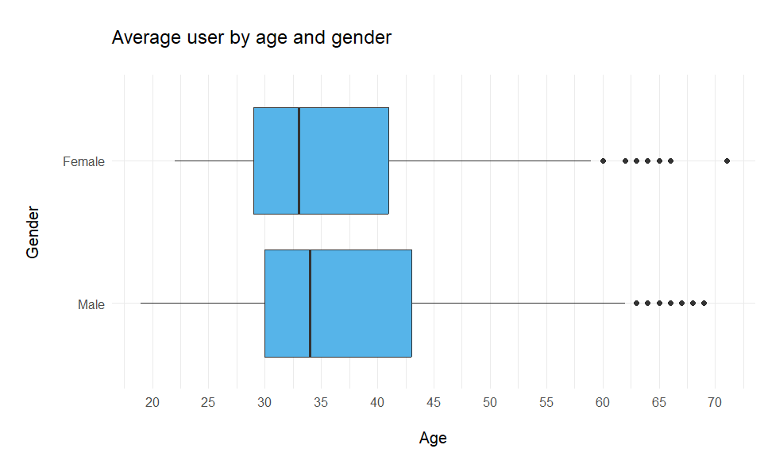

```r
gender_filter <- nyc_bikes_df %>% filter(gender == "Male" | gender == "Female")
gender_filter %>%
  ggplot(aes(x = age, y = gender))+
geom_boxplot(fill = "#56B4E9")+
  scale_x_continuous(breaks = c(10, 15,20,25, 30, 35, 40, 45, 50, 55, 60, 65, 70, 75))+
  theme(axis.text = element_text(size = 12))+
  scale_fill_manual(values = colour_scheme)+
  theme_minimal()+
  labs(
    title = "\nAverage user by age and gender\n",
    x = "\nAge\n",
    y = "\nGender\n"

  )
```

```r
nyc_bikes_df %>% filter(gender == "Female")
```

| bike_id | start_time | stop_time | start_station | start_lat | start_long | end_station | end_lat | end_long | type | birth_year | gender | year | month | day | weekday | date | hire_length | age | hour | minute | second | length_minutes |
| --- | --- | --- | --- | --- | --- | --- | --- | --- | --- | --- | --- | --- | --- | --- | --- | --- | --- | --- | --- | --- | --- | --- |
| 26301 | 2018-03-08 10:25:57 | 2018-03-08 10:59:22 | 3280 | 40.71928 | -74.07126 | 3640 | 40.73367 | -74.06250 | Subscriber | 1953 | Female | 2018 | Mar | 8 | Thursday | 2018-03-08 | 33M 25.3910000324252S | 65 | 0 | 33 | 25.391000032 | 33 |
| 26301 | 2018-03-10 00:27:24 | 2018-03-10 00:38:30 | 3640 | 40.73367 | -74.06250 | 3210 | 40.74268 | -74.05179 | Subscriber | 1995 | Female | 2018 | Mar | 10 | Saturday | 2018-03-10 | 11M 5.91199994087219S | 23 | 0 | 11 | 5.911999941 | 11 |
| 26301 | 2018-03-10 09:08:31 | 2018-03-10 09:20:46 | 3210 | 40.74268 | -74.05179 | 3186 | 40.71959 | -74.04312 | Subscriber | 1995 | Female | 2018 | Mar | 10 | Saturday | 2018-03-10 | 12M 15.4120001792908S | 23 | 0 | 12 | 15.412000179 | 12 |
| 26301 | 2018-03-12 07:07:39 | 2018-03-12 07:10:15 | 3213 | 40.71849 | -74.04773 | 3186 | 40.71959 | -74.04312 | Subscriber | 1962 | Female | 2018 | Mar | 12 | Monday | 2018-03-12 | 2M 36.1049997806549S | 56 | 0 | 2 | 36.104999781 | 3 |
| 26301 | 2018-03-12 08:16:31 | 2018-03-12 08:29:35 | 3269 | 40.72601 | -74.05039 | 3186 | 40.71959 | -74.04312 | Subscriber | 1985 | Female | 2018 | Mar | 12 | Monday | 2018-03-12 | 13M 3.48199987411499S | 33 | 0 | 13 | 3.481999874 | 13 |
| 26301 | 2018-03-12 18:00:45 | 2018-03-12 18:05:35 | 3186 | 40.71959 | -74.04312 | 3269 | 40.72601 | -74.05039 | Subscriber | 1986 | Female | 2018 | Mar | 12 | Monday | 2018-03-12 | 4M 49.5710000991821S | 32 | 0 | 4 | 49.571000099 | 5 |
| 26301 | 2018-03-13 17:45:16 | 2018-03-13 17:50:06 | 3186 | 40.71959 | -74.04312 | 3203 | 40.72760 | -74.04425 | Subscriber | 1977 | Female | 2018 | Mar | 13 | Tuesday | 2018-03-13 | 4M 50.3399999141693S | 41 | 0 | 4 | 50.339999914 | 5 |
| 26301 | 2018-03-13 19:34:40 | 2018-03-13 19:40:06 | 3203 | 40.72760 | -74.04425 | 3273 | 40.72165 | -74.04288 | Subscriber | 1975 | Female | 2018 | Mar | 13 | Tuesday | 2018-03-13 | 5M 26.6670000553131S | 43 | 0 | 5 | 26.667000055 | 5 |
| 26301 | 2018-03-22 21:57:08 | 2018-03-22 22:00:02 | 3272 | 40.72333 | -74.04595 | 3269 | 40.72601 | -74.05039 | Subscriber | 1989 | Female | 2018 | Mar | 22 | Thursday | 2018-03-22 | 2M 53.2019999027252S | 29 | 0 | 2 | 53.201999903 | 3 |
| 26301 | 2018-04-13 09:29:19 | 2018-04-13 09:37:16 | 3272 | 40.72333 | -74.04595 | 3214 | 40.71277 | -74.03649 | Subscriber | 1986 | Female | 2018 | Apr | 13 | Friday | 2018-04-13 | 7M 56.7210001945496S | 32 | 0 | 7 | 56.721000195 | 8 |

[output cut: 920 more lines]

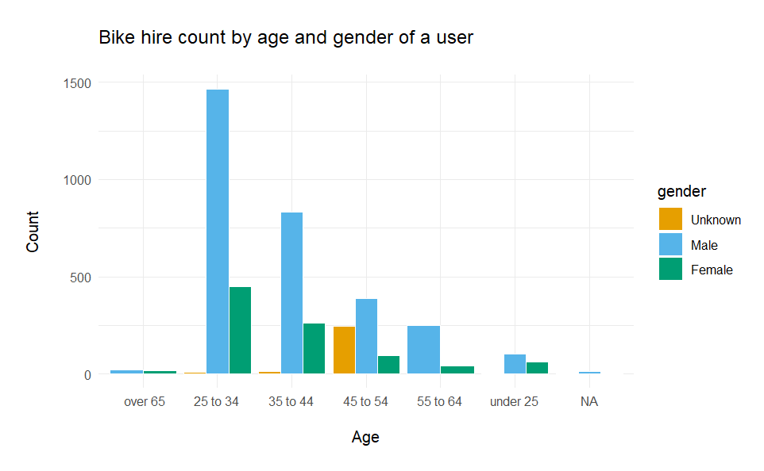

```r
nyc_bikes_df %>%
  ggplot(aes(x = age_range , fill = gender))+
  geom_bar(colour = "white", position = "dodge")+
  theme(axis.text = element_text(size = 12))+
  scale_fill_manual(values = colour_scheme)+
  theme_minimal()+
  labs(
    title = "\nBike hire count by age and gender of a user\n",
    x = "\nAge\n",
    y = "\nCount\n"

  )
```

It looks like males are the main bike users across all age groups. People at the age of 49 tended to avoid disclosing their gender.The youngest bike user was below 20 years old and the oldest near 70 years old.

**Usge by day of the week**

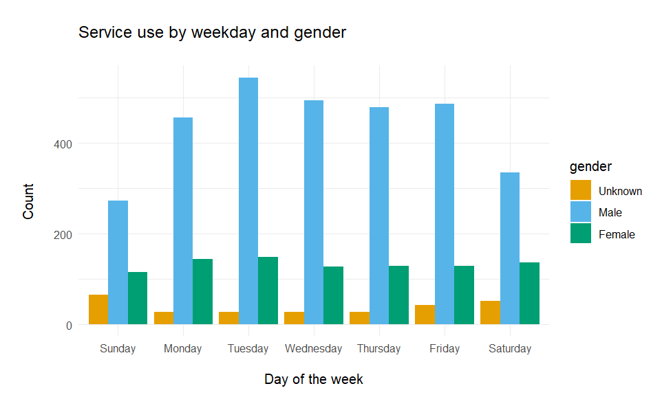

```r
# use spread across the weekdays and by gender
nyc_bikes_df %>%
  ggplot(aes(x = weekday, fill = gender))+
  geom_bar(position = "dodge")+
   theme(axis.text = element_text(size = 12))+
  scale_fill_manual(values = colour_scheme)+
  theme_minimal()+
  labs(

    title = "\nService use by weekday and gender\n",
    x = "\nDay of the week\n",
    y = "\nCount\n"

  )
```

```r
NA
```

the proportion of males travelling by bike seems to be greater than females - we can count proportions maybe

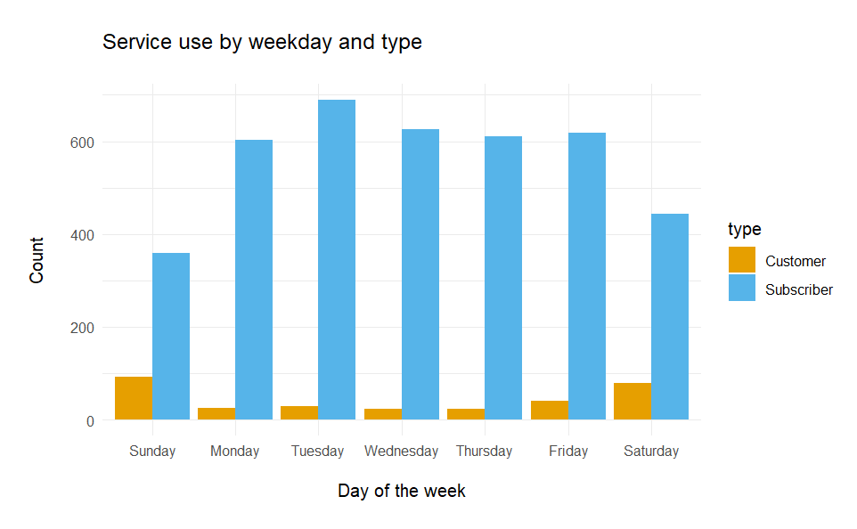

```r
nyc_bikes_df %>%
  ggplot(aes(x = weekday, fill = type), )+
  geom_bar( position = "dodge")+
   theme(axis.text = element_text(size = 12))+
  scale_fill_manual(values = colour_scheme)+
  theme_minimal()+
  labs(

    title = "\nService use by weekday and type\n",
    x = "\nDay of the week\n",
    y = "\nCount\n"

  )
```

```r
avg_male <- nyc_bikes_df %>% filter(gender == "Male") %>% summarise(avg_age_male = mean(age), median_male_age = median(age))
avg_female <- nyc_bikes_df %>% filter(gender == "Female") %>% summarise(avg_age_female = mean(age))


nyc_bikes_df %>% index_by(date) %>% summarise(count = n()) %>%
  ggplot(aes(x = date, y = count))+
  geom_point()+
  geom_smooth()
```

```
Error in UseMethod("index_by") :
  no applicable method for 'index_by' applied to an object of class "c('tbl_df', 'tbl', 'data.frame')"
```

**usage by month**

We can see the number bike hires soars during summer months (Jul and August). We can also notice that colder months of the year tend to attract less bike enthusiasts.

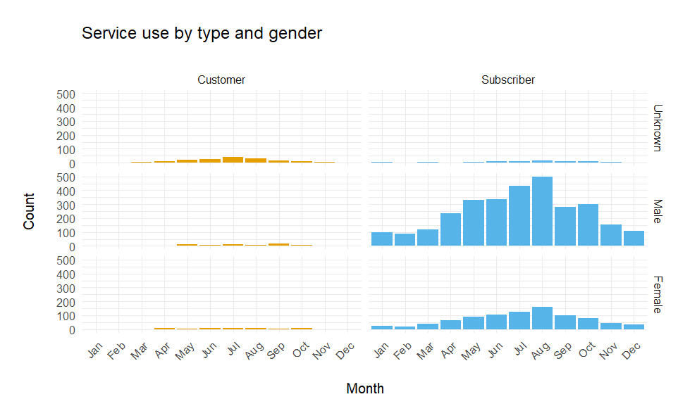

```r
nyc_bikes_df %>%
  ggplot(aes(x = month, group = gender, fill = type)) +
  geom_bar() +
  facet_grid(gender ~ type) +
  theme(axis.text = element_text(size = 12)) +
  scale_fill_manual(values = colour_scheme) +
  theme_minimal() +
  labs(title = "\nService use by type and gender\n",
       x = "\nMonth\n",
       y = "\nCount\n") +
  guides(fill = FALSE) +
  theme(axis.text.x = element_text(angle = 45, hjust = 1))
```

```r
hire_length <- nyc_bikes_df %>% mutate(hour = hour(hire_length),
                                       minute = minute(hire_length),
                                       second = second(hire_length)) %>%
  mutate(length_minutes = round(hour * 60 + minute + second/60)) %>%
  group_by(month) %>%
  summarise(avg_hirelength = mean(length_minutes))


hire_length_count <-
hire_length %>%
  ggplot()+
  geom_point(aes(x= month, y = avg_hirelength))
```